# HW08

Chongdan Pan

2022-03-26

### 1

1. For the best predictor, when $X=2$, we have
   $$\text{MPSE}=\frac{1}{6}(\hat Y-(-2))^2+\frac{1}{6}\hat
   Y^2+\frac{1}{6}(\hat Y-1)^2+\frac{1}{2}(\hat Y-2)^2
   =\frac{1}{6}(\hat Y+2)^2+\frac{1}{2}(\hat Y-2)^2=2\\$$
   $$\hat Y=\begin{cases}
   0 & X=0\\
   1 & X\in\{1,2\}
   \end{cases}$$
   Therefore, the MSPE for the predictor is $2$
2. We have $\mu_Y=\frac{5}{6}, \mu_X=\frac{3}{2},\sigma_X=\frac{7}{12},\sigma_{XY}=0.25$,

therefore, our predictor is $\hat Y=\frac{5}{6}+\frac{3}{7}(X-\frac{3}{2})$

the MPSE is $\frac{77}{36}-\frac{0.25^2}{7/12}=\frac{128}{63}$

3. In this case, the linear predictor is not the best predictor since the variables are not multivariate normal

### 2

```r
A = matrix(c(1, 0.3, 0.3, 1), nrow=2)
b = matrix(c(0.3, 0.2), nrow=2)
solve(A, b)
```

```
##           [,1]
## [1,] 0.2637363
## [2,] 0.1208791
```

Therefore, we have $\phi_1\approx0.264,\phi_2\approx0.121,\rho(3)\approx0.089$

### 3

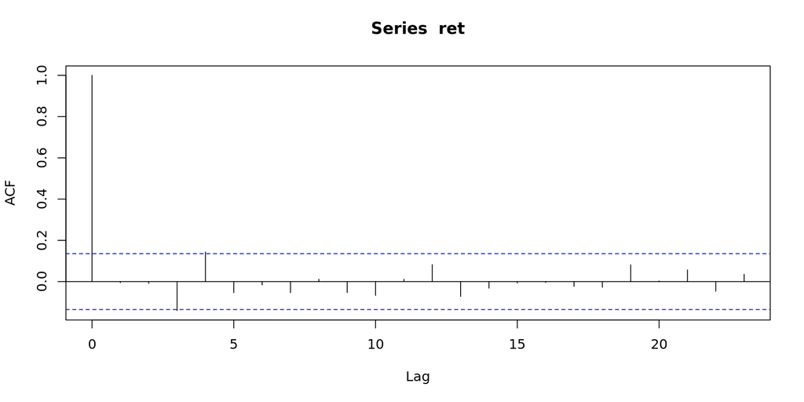

```r
df <- read.csv("../RUT_03_2015-03_2019.csv", header=TRUE)
ret = df$Adj.Close[2:nrow(df)] / df$Adj.Close[1:nrow(df)-1] - 1
acf(ret)
```

```r
Box.test(ret, lag=10, type="Ljung")
```

```
##
##  Box-Ljung test
##
## data:  ret
## X-squared = 11.605, df = 10, p-value = 0.3124
```

The ACF plot shows that there is high correlation when the lag is 3 or 4, which may be fitted by a model. The p-value of the Box-Ljung test is large, so that we can’t reject the null hypothesis, which is $\rho(i)=0$ for i <= 10.

```r
ar_model = ar(ret)
ar_model
```

```
##
## Call:
## ar(x = ret)
##
## Coefficients:
##       1        2        3        4
##  0.0139  -0.0081  -0.1397   0.1445
##
## Order selected 4  sigma^2 estimated as  0.0005455
```

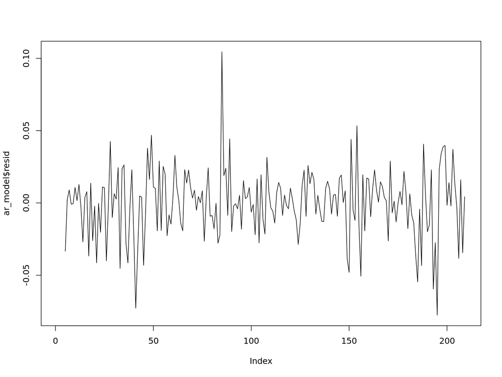

```r
plot(ar_model$resid, type="l")
```

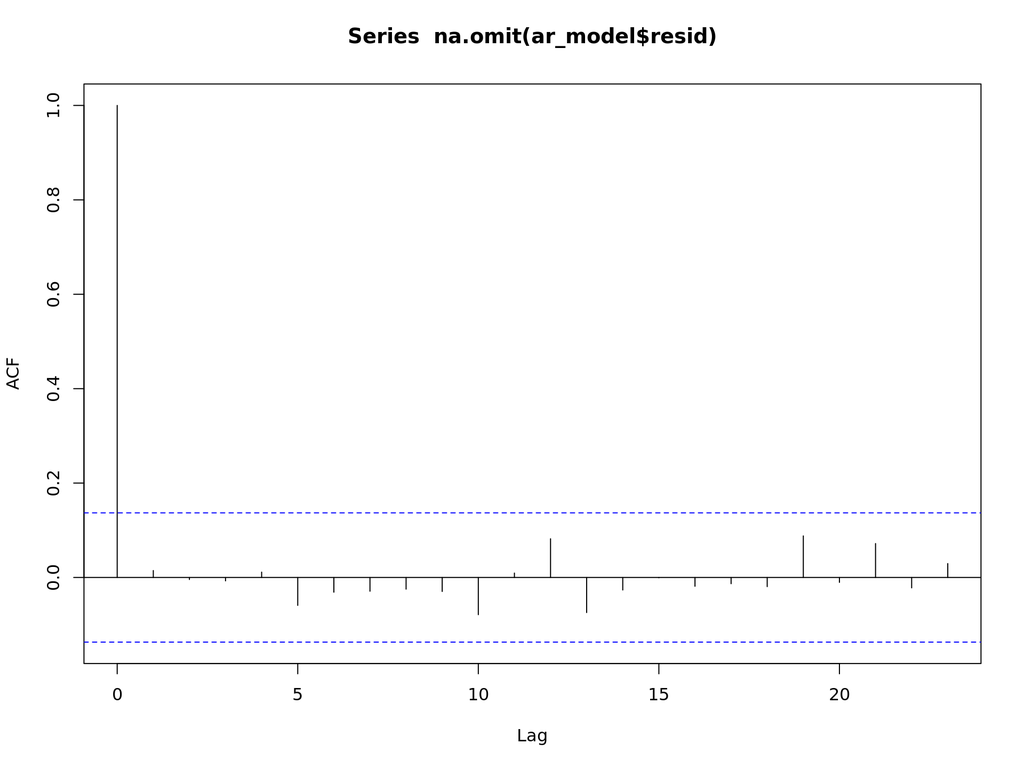

```r
acf(na.omit(ar_model$resid))
```